# Castellano_CS636_Lab04

# 1. **IRIS**

## (1) How many features are numerical data? And how many are categorical data

```r
str(iris[0,])
```

```
'data.frame':   0 obs. of  5 variables:
 $ Sepal.Length: num
 $ Sepal.Width : num
 $ Petal.Length: num
 $ Petal.Width : num
 $ Species     : Factor w/ 3 levels "setosa","versicolor",..:
```

There are 5 features, 4 numerical and 1 categorical.

## (2) Histogram

Make histogram for the numerical features, to see how they distribute

```r
par(mfrow=c(2,2))
hist(iris$Petal.Length,main='Histogram of Petal Lenght',xlab='Petal Length (mm)',col = '#66FF66')
hist(iris$Petal.Width,main='Histogram of Petal Width',xlab='Petal Width (mm)')
```

[figure not shown]

```r
hist(iris$Sepal.Length,main='Histogram of Sepal Lenght',xlab='Sepal Length (mm)')
hist(iris$Petal.Length,main='Histogram of Sepal Width',xlab='Sepal Width (mm)')
```

## (3) Table

Make table for the categorical features, to see how they distribute

```r
table(iris$Species)
```

```
    setosa versicolor  virginica
        50         50         50
```

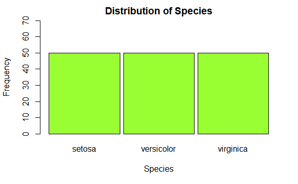

```r
barplot(table(iris$Species), main = 'Distribution of Species', xlab = 'Species', ylab = 'Frequency',space = .05, col = '#99ff33', ylim = c(0,70) )
```

```r
NA
NA
```

# 2. **Rivers**

The data set rivers contains the lengths (in miles) of 141 major rivers in North America.

## (1) What proportion are less than 500 miles long?

```r
t = length(rivers[rivers < 500])
p = t/length(rivers)
p
```

```
[1] 0.5815603
```

## (2) What proportion are less than the mean length?

```r
t = length(rivers[rivers < mean(rivers)])
p = t/length(rivers)
p
```

```
[1] 0.6666667
```

## (3) What is the 0.75 quantile?

```r
third = quantile(rivers)
third
```

```
  0%  25%  50%  75% 100%
 135  310  425  680 3710
```

The 0.75 quantile is 680miles.

# 3. **pi2000**

Fit a density estimate to the data set pi2000 (UsingR). Compare with the appropriate histogram. Why might you want to add an argument like breaks =0:10-0.5 to hist()?

```r
data(pi2000)
par(mfrow=c(1,2))
x <- pi2000
h <- hist(x, breaks = 0:10-0.5, col="light green", xlab='Digits', main='Histogram of Pi Digits',prob=T)
xfit <- seq(min(x),max(x),length=9)
yfit <- dunif(xfit,0,9)
yfit <- yfit*.8
lines(xfit,yfit,col='blue',lwd=2)
```

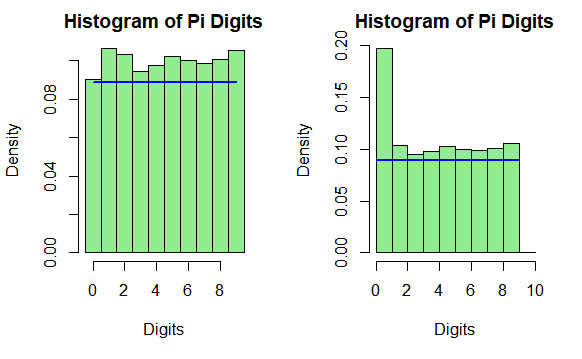

```r
h <- hist(x, breaks = 0:10, col="light green", xlab='Digits', main='Histogram of Pi Digits',prob=T)
xfit <- seq(min(x),max(x),length=9)
yfit <- dunif(xfit,0,9)
yfit <- yfit*.8
lines(xfit,yfit,col='blue',lwd=2)
```

Using breaks = 0:10-0.5 helps display the histogram more accurately since using breaks = 10 for example, causes the histogram to be plotted out of proportion.

# 4. **MASS**

The data set DDT (MASS) contains independent measurements of the pesticide DDT on kale. Make a histogram and a boxplot of the data. From these, estimate the mean and standard deviation. Check your answers with the appropriate functions.

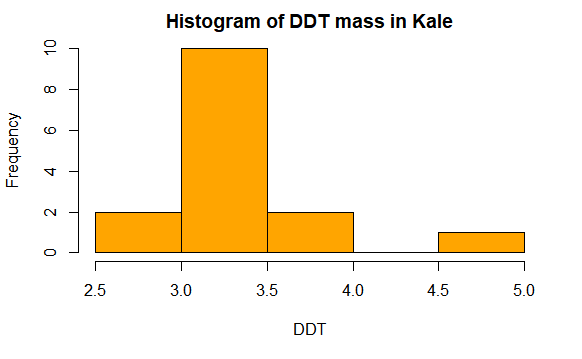

```r
hist(DDT,breaks=5,col="orange", main="Histogram of DDT mass in Kale")
```

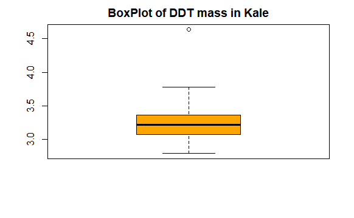

```r
boxplot(DDT,col="orange",main="BoxPlot of DDT mass in Kale")
```

### **MASS Actuals**

```r
str(DDT)
```

```
 num [1:15] 2.79 2.93 3.22 3.78 3.22 3.38 3.18 3.33 3.34 3.06 ...
```

```r
sprintf('Mean mass is %s ', mean(DDT))
```

```
[1] "Mean mass is 3.328 "
```

```r
sprintf('Standard deviation is %.2f ', sd(DDT))
```

```
[1] "Standard deviation is 0.44 "
```

# 5. **Two Graphics**

It can be illuminating to view two different graphics of the same data set at once. A simple way to stack graphics is to specify that a figure will contain two graphics by using the command

> par(mfrow=c(2,1)

> hist(x)

> boxplot(x, horizontal=TRUE)

will produce stacked graphics. (The graphics device will remain divided until you change it back with a command such as par (mfrow=c(1, 1)) or close the device.) For the data set lawsuits (UsingR), make stacked graphics of lawsuits and log (lawsuits). Could you have guessed where the middle 50% of the data would have been without the help of the boxplot?

```r
par(mfrow=c(2,2))
x <- (lawsuits)
boxplot(x, col="#0099ff", main='Boxplot', xlab='Lawsuits')
boxplot(log(x), col='#0099ff', horizontal=TRUE, main='Boxplot',
xlab='log(Lawsuits)')
```

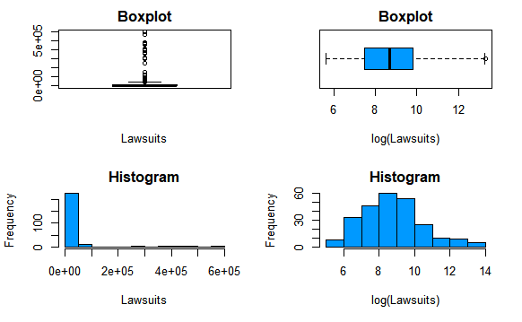

```r
hist(x, col="#0099ff", main='Histogram', xlab='Lawsuits')
hist(log(x), col='#0099ff', main='Histogram',
xlab='log(Lawsuits)')
```

Determining the median of the data would have been impossible without the aid of box plot of log(lawsuits).

# 6. **Sex, Age, and Smoking**

Let sex = c(1,1,1,1,2,2,2,2,2,2); smoking = c(1,0,1,0,1,0,0,0,1,1); age=c(31:40) in R. A data frame is constructed as zz = data.frame(sex, smoking, age). Give the results of following R commands: 1) apply(zz[-1,], 2, min)

```r
sex <- c(1,1,1,1,2,2,2,2,2,2)
smoking <- c(1,0,1,0,1,0,0,0,1,1)
age <- c(31:40)
zz <- data.frame(sex, smoking, age)
zz
```

| sex | smoking | age |
| --- | --- | --- |
| 1 | 1 | 31 |
| 1 | 0 | 32 |
| 1 | 1 | 33 |
| 1 | 0 | 34 |
| 2 | 1 | 35 |
| 2 | 0 | 36 |
| 2 | 0 | 37 |
| 2 | 0 | 38 |
| 2 | 1 | 39 |
| 2 | 1 | 40 |

```r
apply(zz[-1,], 2, min)
```

```
    sex smoking     age
      1       0      32
```

```r
zz[zz[,3]>35,]
```

|  | sex | smoking | age |
| --- | --- | --- | --- |
| 6 | 2 | 0 | 36 |
| 7 | 2 | 0 | 37 |
| 8 | 2 | 0 | 38 |
| 9 | 2 | 1 | 39 |
| 10 | 2 | 1 | 40 |

```r
zz[order(zz["smoking"], zz["age"]),  ]
```

|  | sex | smoking | age |
| --- | --- | --- | --- |
| 2 | 1 | 0 | 32 |
| 4 | 1 | 0 | 34 |
| 6 | 2 | 0 | 36 |
| 7 | 2 | 0 | 37 |
| 8 | 2 | 0 | 38 |
| 1 | 1 | 1 | 31 |
| 3 | 1 | 1 | 33 |
| 5 | 2 | 1 | 35 |
| 9 | 2 | 1 | 39 |
| 10 | 2 | 1 | 40 |

```r
subset(zz, zz["sex"]==1)
```

|  | sex | smoking | age |
| --- | --- | --- | --- |
| 1 | 1 | 1 | 31 |
| 2 | 1 | 0 | 32 |
| 3 | 1 | 1 | 33 |
| 4 | 1 | 0 | 34 |

```r
tapply(zz$age, zz$smoking, max)
```

```
 0  1
38 40
```

```r
apply(zz[,-3], 1, function(x){ sum(x) })
```

```
 [1] 2 1 2 1 3 2 2 2 3 3
```